# Tugas Pertemuan 6

## Analisis Sisaan

### Eksplorasi Sisaan

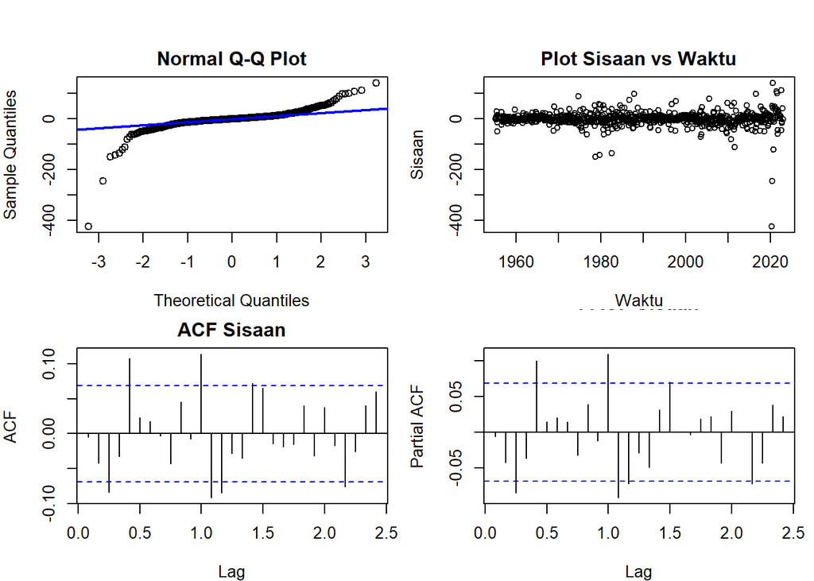

```r
sisaan.da <- model4.da$residuals

par(mfrow = c(2,2),
    mar = c(4,4,2,1),
    oma = c(0,0,2,0))

# Q-Q Plot
qqnorm(sisaan.da, main = "Normal Q-Q Plot")
qqline(sisaan.da, col = "blue", lwd = 2)

# Plot Sisaan vs Waktu
plot(sisaan.da, type = "p",
     main = "Plot Sisaan vs Waktu",
     xlab = "Waktu", ylab = "Sisaan")

# ACF
acf(sisaan.da, main = "ACF Sisaan")

# PACF
pacf(sisaan.da, main = "PACF Sisaan")
```

**Catatan:** Indikasi visual ini masih bersifat eksploratif. Keabsahan asumsi *white noise* dan kenormalan sisaan selanjutnya akan diverifikasi secara pasti melalui **uji formal** (seperti uji Ljung-Box dan uji Jarque-Bera / Shapiro-Wilk).

### Uji Formal

#### Normalitas

```r
#1) Sisaan Menyebar Normal
ks.test(sisaan.da,"pnorm")
```

```
##
##  Asymptotic one-sample Kolmogorov-Smirnov test
##
## data:  sisaan.da
## D = 0.41174, p-value < 2.2e-16
## alternative hypothesis: two-sided
```

- **Hipotesis**:
  - $H_0$: Sisaan menyebar normal
  - $H_1$: Sisaan tidak menyebar normal
- **Hasil Pengujian**: Nilai statistik uji $D = 0{,}41174$ dengan $p\text{-value} < 2{,}2 \times 10^{-16}$.
- **Keputusan**: **Tolak** $H_0$ karena $p\text{-value} < 0{,}05$.
- **Kesimpulan**: Sisaan **tidak menyebar normal**. Hal ini dipicu oleh keberadaan pencilan (*outlier*) ekstrem negatif pada periode krisis COVID-19 tahun 2020.

#### Sisaan Saling Bebas

```r
Box.test(sisaan.da, type = "Ljung")
```

```
##
##  Box-Ljung test
##
## data:  sisaan.da
## X-squared = 0.022939, df = 1, p-value = 0.8796
```

#### Homogenitas Ragam

```r
#3) Sisaan homogen
Box.test((sisaan.da)^2, type = "Ljung")
```

```
##
##  Box-Ljung test
##
## data:  (sisaan.da)^2
## X-squared = 71.585, df = 1, p-value < 2.2e-16
```

- **Hipotesis**:
  - $H_0$: Ragam sisaan homogen (*homoscedastic*)
  - $H_1$: Ragam sisaan tidak homogen (*heteroscedastic*)
- **Hasil Pengujian**: Nilai statistik uji $\chi^2 = 71{,}585$ ($df = 1$) dengan $p\text{-value} < 2{,}2 \times 10^{-16}$.
- **Keputusan**: **Tolak** $H_0$ karena $p\text{-value} < 0{,}05$.
- **Kesimpulan**: Terdapat indikasi **ragam sisaan tidak homogen (heteroskedastisitas)** yang disebabkan oleh lonjakan ragam (*volatility spike*) saat *shock* pandemi COVID-19.

#### Nilai Tengah Sisaan sama dengan 0

```r
#4) Nilai tengah sisaan sama dengan nol
t.test(sisaan.da, mu = 0, conf.level = 0.95)
```

```
##
##  One Sample t-test
##
## data:  sisaan.da
## t = -0.69487, df = 814, p-value = 0.4873
## alternative hypothesis: true mean is not equal to 0
## 95 percent confidence interval:
##  -2.693740  1.285184
## sample estimates:
##  mean of x
## -0.7042782
```

- **Hipotesis**:
  - $H_0: \mu_e = 0$ (Nilai tengah sisaan sama dengan nol)
  - $H_1: \mu_e \neq 0$ (Nilai tengah sisaan tidak sama dengan nol)
- **Hasil Pengujian**: Nilai statistik uji $t = -0{,}69487$ ($df = 814$) dengan $p\text{-value} = 0{,}4873$ dan rata-rata sisaan $\hat{\mu} = -0{,}7043$.
- **Keputusan**: **Gagal Tolak** $H_0$ karena $p\text{-value} > 0{,}05$.
- **Kesimpulan**: Nilai tengah sisaan **sama dengan nol secara statistik**.

## Overfitting

Tahapan selanjutnya adalah overfitting dilakukan dengan menaikkan orde AR(p) dan MA(q) dari model ARIMA(0,1,2) Kandidat model overfitting adalah ARIMA(1,1,2) dan ARIMA(0,1,3). Karena model hasil overfitting sudah termasuk di dalam model tentatif dan hasilnya tidak lebih baik, maka model terbaik yang dipilih adalah ARIMA(0,1,2) dilanjutkan dengan peramalan.

### Model ARIMA(1,1,2)

```r
model7.da=Arima(train.diff, order=c(1,1,2),method="ML")
summary(model7.da)
```

```
## Series: train.diff
## ARIMA(1,1,2)
##
## Coefficients:
##           ar1      ma1      ma2
##       -0.1416  -0.7294  -0.2536
## s.e.   0.2357   0.2293   0.2252
##
## sigma^2 = 840.4:  log likelihood = -3895.93
## AIC=7799.86   AICc=7799.91   BIC=7818.66
##
## Training set error measures:
##                      ME    RMSE      MAE  MPE MAPE      MASE        ACF1
## Training set -0.6855503 28.9187 14.79866 -Inf  Inf 0.7205682 -0.00363592
```

```r
lmtest::coeftest(model7.da)
```

```
##
## z test of coefficients:
##
##     Estimate Std. Error z value Pr(>|z|)
## ar1 -0.14158    0.23575 -0.6006 0.548126
## ma1 -0.72939    0.22932 -3.1807 0.001469 **
## ma2 -0.25356    0.22518 -1.1261 0.260143
## ---
## Signif. codes:  0 '***' 0.001 '**' 0.01 '*' 0.05 '.' 0.1 ' ' 1
```

- **Hasil Estimasi Koefisien**:
  - Parameter $\hat{\phi}_1 = -0{,}14158$ ($p\text{-value} = 0{,}548126$)
  - Parameter $\hat{\theta}_1 = -0{,}72939$ ($p\text{-value} = 0{,}001469$)
  - Parameter $\hat{\theta}_2 = -0{,}25356$ ($p\text{-value} = 0{,}260143$)
- **Evaluasi Parameter**:
  - Parameter $AR(1)$ tambahan terbukti **tidak signifikan** secara statistik ($p\text{-value} = 0{,}5481 > 0{,}05$).
  - Parameter $MA(2)$ yang sebelumnya signifikan pada model ARIMA(0,1,2) kini menjadi **tidak signifikan** ($p\text{-value} = 0{,}2601 > 0{,}05$).
- **Evaluasi Kriteria Informasi**:
  - Nilai AIC meningkat dari $7798{,}26$ (pada ARIMA(0,1,2)) menjadi $7799{,}86$.
  - Nilai BIC meningkat dari $7812{,}36$ (pada ARIMA(0,1,2)) menjadi $7818{,}66$.

**Kesimpulan Overfitting:** Penambahan orde pada model *overfitted* **ARIMA(1,1,2)** menghasilkan parameter tambahan yang tidak signifikan serta menyebabkan peningkatan nilai AIC dan BIC. Hal ini membuktikan bahwa model **ARIMA(0,1,2)** sudah bersifat *parsimonious* (paling efisien/pas) dan tidak memerlukan penambahan orde lebih lanjut.

### Model ARIMA(0,1,3)

```r
model8.da=Arima(train.diff, order=c(0,1,3),method="ML")
summary(model8.da)
```

```
## Series: train.diff
## ARIMA(0,1,3)
##
## Coefficients:
##           ma1      ma2     ma3
##       -0.8781  -0.1452  0.0390
## s.e.   0.0358   0.0447  0.0385
##
## sigma^2 = 839.8:  log likelihood = -3895.62
## AIC=7799.24   AICc=7799.29   BIC=7818.05
##
## Training set error measures:
##                      ME    RMSE      MAE  MPE MAPE      MASE        ACF1
## Training set -0.6498097 28.9081 14.78769 -Inf  Inf 0.7200343 0.001512198
```

```r
lmtest::coeftest(model8.da)
```

```
##
## z test of coefficients:
##
##      Estimate Std. Error  z value  Pr(>|z|)
## ma1 -0.878051   0.035849 -24.4931 < 2.2e-16 ***
## ma2 -0.145223   0.044733  -3.2465  0.001168 **
## ma3  0.038963   0.038507   1.0118  0.311611
## ---
## Signif. codes:  0 '***' 0.001 '**' 0.01 '*' 0.05 '.' 0.1 ' ' 1
```

- **Hasil Estimasi Koefisien**:
  - Parameter $\hat{\theta}_1 = -0{,}878051$ ($p\text{-value} < 2{,}2 \times 10^{-16}$)
  - Parameter $\hat{\theta}_2 = -0{,}145223$ ($p\text{-value} = 0{,}001168$)
  - Parameter $\hat{\theta}_3 = 0{,}038963$ ($p\text{-value} = 0{,}311611$)
- **Evaluasi Parameter**:
  - Parameter $MA(3)$ tambahan terbukti **tidak signifikan** secara statistik ($p\text{-value} = 0{,}3116 > 0{,}05$).
- **Evaluasi Kriteria Informasi**:
  - Nilai AIC meningkat dari $7798{,}26$ (pada ARIMA(0,1,2)) menjadi $7799{,}24$.
  - Nilai BIC meningkat dari $7812{,}36$ (pada ARIMA(0,1,2)) meledak menjadi $7818{,}05$.

### Kesimpulan Keseluruhan Uji Overfitting

Hasil pengujian *overfitting* baik melalui penambahan orde AR menjadi **ARIMA(1,1,2)** maupun penambahan orde MA menjadi **ARIMA(0,1,3)** secara konsisten menghasilkan parameter tambahan yang **tidak signifikan secara statistik** ($p\text{-value} > 0{,}05$) serta meningkatkan nilai AIC dan BIC.

Hal ini membuktikan secara ilmiah bahwa model **ARIMA(0,1,2)** sudah bersifat *parsimonious* (sangat hemat parameter), valid, dan merupakan **model final paling optimal** untuk digunakan pada tahap peramalan (*forecasting*).

## Model Terbaik: ARIMA(0,1,2)

```r
model_beneran <- Arima(train.ts, order = c(0,2,2), method = "ML")
summary(model_beneran)
```

```
## Series: train.ts
## ARIMA(0,2,2)
##
## Coefficients:
##           ma1      ma2
##       -0.8682  -0.1173
## s.e.   0.0356   0.0357
##
## sigma^2 = 839.8:  log likelihood = -3896.13
## AIC=7798.26   AICc=7798.29   BIC=7812.36
##
## Training set error measures:
##                      ME     RMSE      MAE         MPE     MAPE      MASE
## Training set -0.7052968 28.90799 14.79262 -0.00641045 0.275262 0.1212411
##                      ACF1
## Training set -0.005323913
```

```r
lmtest::coeftest(model_beneran)
```

```
##
## z test of coefficients:
##
##      Estimate Std. Error  z value  Pr(>|z|)
## ma1 -0.868162   0.035623 -24.3708 < 2.2e-16 ***
## ma2 -0.117298   0.035730  -3.2829  0.001028 **
## ---
## Signif. codes:  0 '***' 0.001 '**' 0.01 '*' 0.05 '.' 0.1 ' ' 1
```

## Peramalan

```r
# --- 1. FORECAST DATA SELISIH ---
# Merediksi data selisih sejumlah periode data test.ts
ramalan.da <- forecast::forecast(model4.da, h = length(test.ts))
data.ramalan.da <- ramalan.da$mean

# --- 2. INVERSE DIFFERENCING ---
# Ambil titik terakhir dari data training asli
pt_akhir_train <- tail(train.ts, 1)

# Kembalikan ke skala asli
forecast_inv <- diffinv(data.ramalan.da, differences = 1, xi = pt_akhir_train)
hasil <- forecast_inv[-1] # Buang titik awal xi

# --- 3. BANDINGKAN AKTUAL VS FORECAST ---
perbandingan.da <- cbind(
  Aktual   = test.ts,
  Forecast = hasil
)
print(head(perbandingan.da, 10))
```

```
##          Aktual Forecast
## Jan 2023 7906.9 7876.650
## Feb 2023 7927.9 7877.982
## Mar 2023 7934.6 7879.315
## Apr 2023 7939.8 7880.647
## May 2023 7958.2 7881.979
## Jun 2023 7969.8 7883.311
## Jul 2023 7994.3 7884.643
## Aug 2023 8021.3 7885.975
## Sep 2023 8030.4 7887.307
## Oct 2023 8038.0 7888.640
```

```r
# --- 4. HITUNG AKURASI PERAMALAN ---
akurasi_test <- accuracy(hasil, test.ts)
print(akurasi_test)
```

```
##                ME     RMSE      MAE      MPE     MAPE      ACF1 Theil's U
## Test set 212.8206 230.1916 212.8206 2.610109 2.610109 0.9120338  16.21982
```

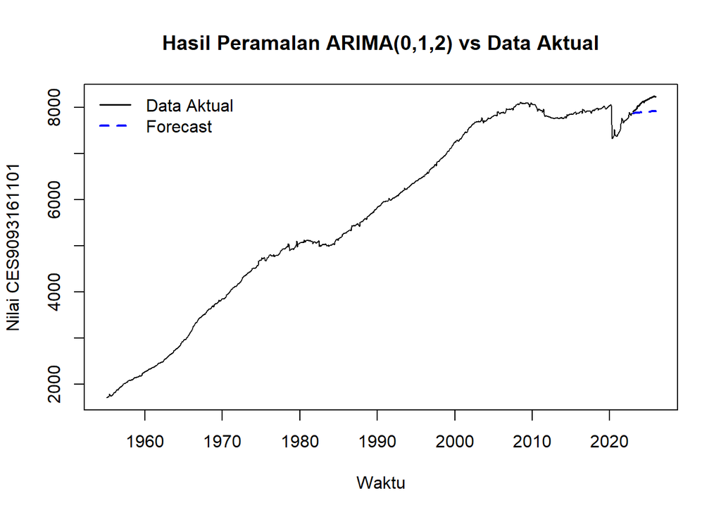

```r
# --- 5. PLOT DATA AKTUAL VS FORECAST ---
# Gabungkan plot data asli dengan garis ramalan
plot(train.ts, xlim = c(time(train.ts)[1], time(test.ts)[length(test.ts)]),
     ylim = range(c(train.ts, test.ts, hasil)),
     xlab = "Waktu", ylab = "Nilai CES9093161101", main = "Hasil Peramalan ARIMA(0,1,2) vs Data Aktual")

# Tambahkan garis data test (aktual)
lines(test.ts, col = "black", lty = 1, lwd = 1.5)

# Tambahkan garis ramalan (forecast)
lines(ts(hasil, start = start(test.ts), frequency = frequency(test.ts)),
      col = "blue", lty = 2, lwd = 2)

# Legend
legend("topleft",
       legend = c("Data Aktual", "Forecast"),
       col = c("black", "blue"),
       lty = c(1, 2), lwd = c(1.5, 2), bty = "n")
```